# Stats 506, F18, Problem Set 3

Zi Wang, tlwangzi@umich.edu

11/21/2018

## Question 1

### a.

**Table 1.** Percent of homes with stucco construction as the major outside wall material within each division.

| Division | Precent of Stucco Homes (95% CI) |
| --- | --- |
| Mountain South | 64.2% (55.4, 73.0) |
| Pacific | 44.6% (41.3, 47.9) |
| Mountain North | 16.6% (10.2, 23.0) |
| South Atlantic | 10.6% ( 7.8, 13.4) |
| West North Central | 4.9% ( 0.9, 8.8) |
| West South Central | 3.0% ( 1.6, 4.3) |
| Middle Atlantic | 2.1% ( 0.6, 3.5) |
| New England | 1.2% ( 0.0, 2.8) |
| East North Central | 0.7% ( 0.1, 1.2) |
| East South Central | 0.4% ( 0.0, 1.2) |

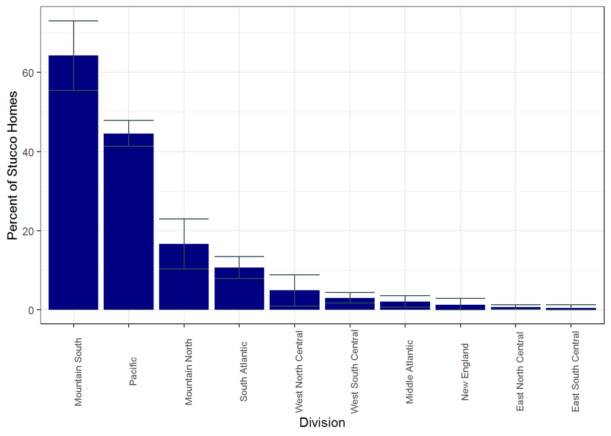

**Figure 1.** Percent of homes with stucco construction as the major outside wall material within each division.

### b.

**Table 2.** Average total electricity usage in kilowatt hours in each division.

| Division | Average total electricity usage in kilowatt hours(95% CI) |
| --- | --- |
| East South Central | 14,536, (13,320 - 15,752) |
| West South Central | 14,324, (13,495 - 15,153) |
| South Atlantic | 13,447, (12,904 - 13,989) |
| West North Central | 10,524, ( 9,635 - 11,413) |
| Mountain South | 10,442, ( 7,950 - 12,934) |
| East North Central | 9,129, ( 8,730 - 9,528) |
| Middle Atlantic | 8,465, ( 8,071 - 8,860) |
| Mountain North | 8,384, ( 7,121 - 9,648) |
| Pacific | 8,100, ( 7,750 - 8,450) |
| New England | 7,515, ( 6,472 - 8,557) |

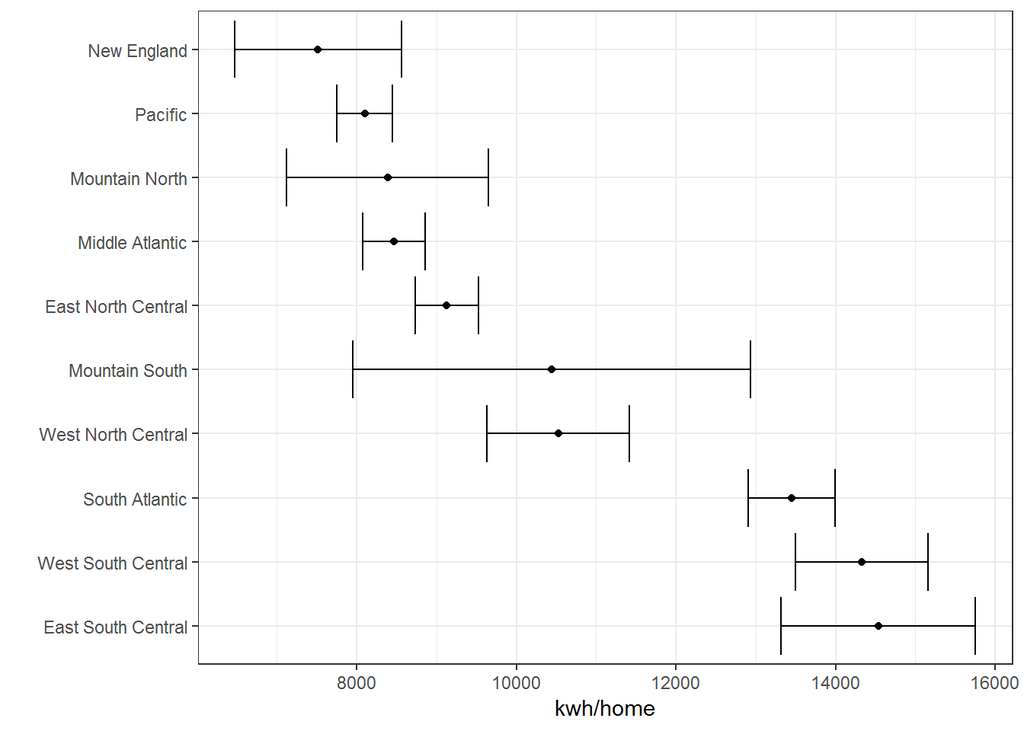

**Figure 2.** Average total electricity usage in kilowatt hours in each division.

**Table 3.** Average total electricity usage in kilowatt hours in each division stratified by urban and rural status.

| Division | Average kwh in Rural status(95% CI) | Average kwh in Urban status(95% CI) |
| --- | --- | --- |
| East South Central | 16,333, (14,088 - 18,578) | 13,747, (12,197 - 15,298) |
| West South Central | 16,317, (14,067 - 18,567) | 13,629, (12,852 - 14,405) |
| South Atlantic | 15,942, (14,839 - 17,045) | 12,725, (12,134 - 13,316) |
| West North Central | 14,174, (12,608 - 15,740) | 9,467, ( 8,722 - 10,211) |
| East North Central | 13,500, (12,022 - 14,978) | 7,980, ( 7,552 - 8,408) |
| Pacific | 14,115, (12,001 - 16,229) | 7,349, ( 6,905 - 7,793) |
| Middle Atlantic | 12,223, (10,633 - 13,814) | 7,987, ( 7,659 - 8,316) |
| Mountain South | 8,610, ( 6,536 - 10,685) | 10,743, ( 8,178 - 13,308) |
| Mountain North | 9,356, ( 5,698 - 13,014) | 8,099, ( 7,396 - 8,803) |
| New England | 9,001, ( 6,766 - 11,236) | 6,964, ( 5,918 - 8,010) |

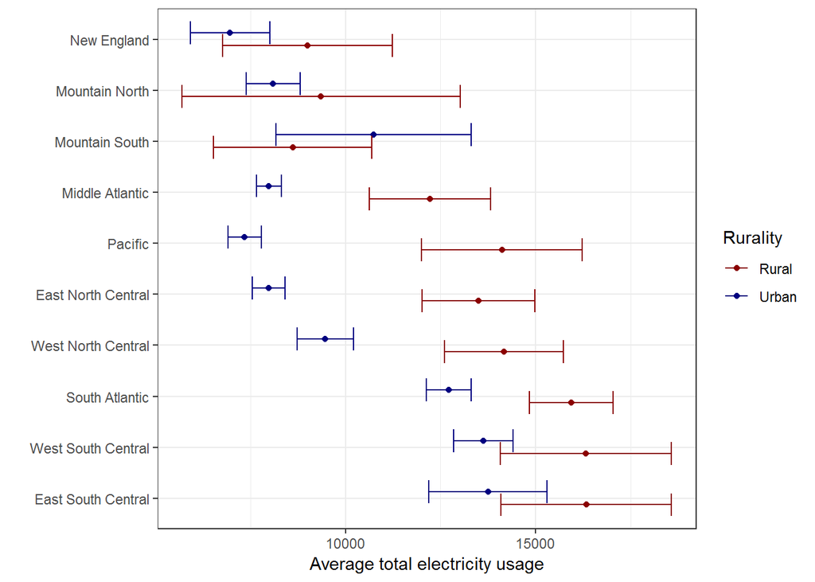

**Figure 3.** Average total electricity usage in kilowatt hours in each division stratified by urban and rural status.

### c.

**Table 4.** Disparity between urban and rural areas in terms of the proportion of homes with internet access.

| Census Division | Urban Internet Access, % (95% CI) | Rural Internet Access, % (95% CI) | Difference, % (95% CI) |
| --- | --- | --- | --- |
| Mountain South | 85.3 (81.3, 89.2) | 66.7 (58.3, 75.2) | 18.5%( 7.2,29.8) |
| East South Central | 78.4 (70.5, 86.2) | 69.0 (63.5, 74.6) | 9.3%(-1.4,20.1) |
| West North Central | 88.0 (84.6, 91.4) | 80.3 (71.5, 89.2) | 7.7%(-2.5,17.8) |
| Mountain North | 87.4 (82.0, 92.9) | 81.9 (73.8, 90.0) | 5.5%(-6.2,17.2) |
| West South Central | 81.6 (76.4, 86.8) | 76.5 (72.1, 80.9) | 5.1%(-2.3,12.5) |
| Pacific | 88.7 (86.2, 91.2) | 85.3 (77.4, 93.1) | 3.4%(-4.5,11.4) |
| South Atlantic | 85.3 (82.6, 88.0) | 82.0 (76.3, 87.8) | 3.3%(-3.5,10.1) |
| New England | 87.6 (82.5, 92.6) | 85.8 (82.4, 89.2) | 1.8%(-2.5, 6.0) |
| East North Central | 86.3 (83.8, 88.7) | 86.2 (81.6, 90.8) | 0.0%(-5.3, 5.4) |
| Middle Atlantic | 89.3 (83.9, 94.8) | 91.3 (85.3, 97.3) | -1.9%(-9.1, 5.2) |

The Mountain South Division has the largest disparity between urban and rural areas in terms of the proportion of homes with internet access: 18.5%

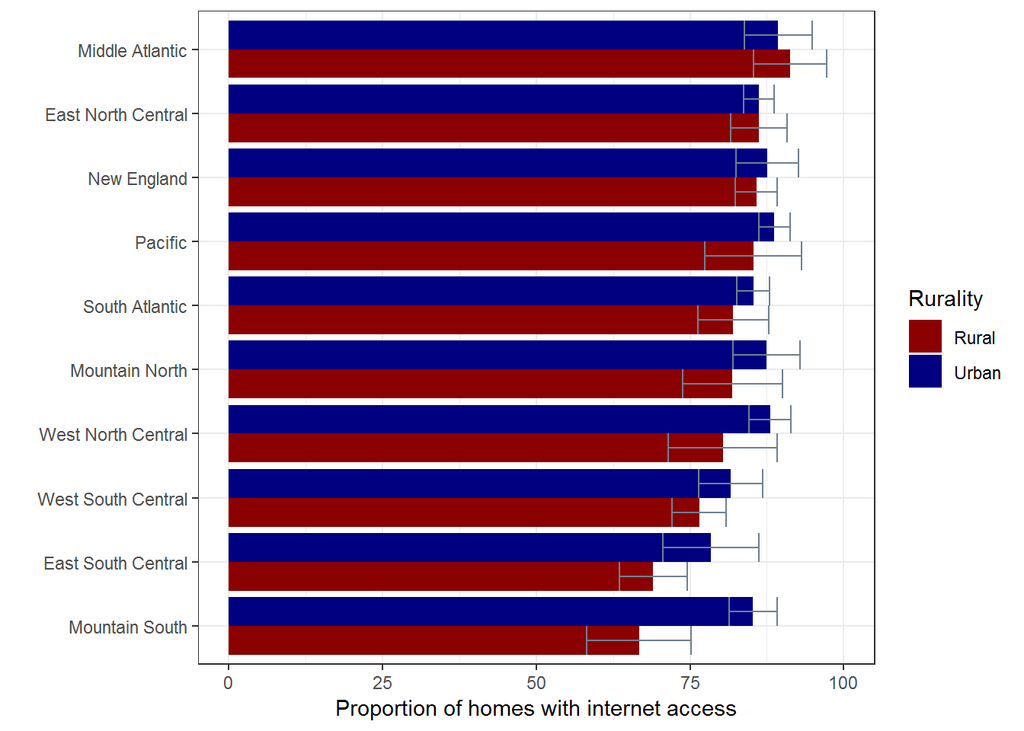

**Figure 4.** Disparity between urban and rural areas in terms of the proportion of homes with internet access.

### d.

Question: What percent of homes have rented(KOWNRENT == 2) within each division? Which division has the highest proportion? Which has the lowest?

**Table 5.** Percent of homes rented(KOWNRENT == 2) within each division.

[output not shown]

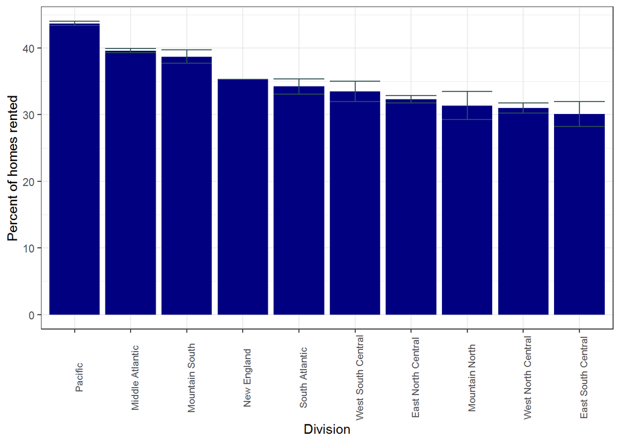

**Figure 5.** Percent of homes rented(KOWNRENT == 2) within each division.

The Pacific division has the highest proportion: 43.7%.  
The East South Central Division has the lowest proportion: 30.1%.

## Question 2

### a.

The function:

```r
MC_analysis = function(X, beta, sigma, mc_rep){
  result = matrix(0, nrow = p, ncol = mc_rep)
  var = rep(0,p)
  QR = qr(t(X) %*% X)
  R = qr.R(QR)
  Q = qr.Q(QR)
  for (i in 1:mc_rep){
    Y = X %*% beta
    Y1 = rnorm(n, mean = 0, sd = sigma)
    dim(Y1) = c(n,1)
    Y = Y + Y1
    # i.
    beta_hat = solve(R, t(Q) %*% t(X) %*% Y)
    ## ii.
    Y_hat = X %*% beta_hat
    sigmasq_hat = sum((Y-Y_hat)^2)/(n-p)
    ## iii.
    v = (sigmasq_hat) * solve(R) %*% t(Q)
    var = diag(v)
    ## iv.
    Z = beta_hat/sqrt(var)
    result[,i] = 2*(1-pnorm(abs(Z)))
  }
  result
}
```

Test the function, show the maximum of the finite precision error:

```r
# Test the function: MC_analysis()
n = 1000
p = 100
mc_rep = 1
sigma = 1
beta = rep(0,p)
for (i in 1:10) beta[i] = sigma^2
X = rnorm(n*p)
dim(X) = c(n,p)
set.seed(42)
test = MC_analysis(X, beta, sigma, mc_rep)
set.seed(42)
Y = X%*%beta + rnorm(n, mean = 0, sd = sigma)
fit0 = lm(Y ~ 0 + X)
p_value = summary(fit0)$coefficients[,'Pr(>|t|)']
ans = max(abs(test[,1]-p_value))
ans
```

```
## [1] 0.0003515363
```

### b.

```r
n = 1000
p = 100
sigma = 30                   # sigma
S = matrix(0, nrow = p, ncol = p)
for (i in 1:p)
  S[i,i] = runif(1, min = 1, max = p)
R = chol(S)
X = rnorm(n*p)
dim(X) = c(n,p)
X = X %*% R                  # X
beta = rep(0,p)
for (i in 1:10) beta[i] = 1  # beta
mc_rep = 1000                # mc_rep
result = MC_analysis(X, beta, sigma, mc_rep)
```

### c.

The evaluate() function:

```r
evaluate = function(result, indice){
  alpha = 0.05
  m = qnorm(.975)
  p = nrow(result)
  mc_rep = ncol(result)
  FWER = rep(0,mc_rep)
  FDR = rep(0,mc_rep)
  Sensitivity = rep(0,mc_rep)
  Specificity = rep(0,mc_rep)
  for (j in 1:mc_rep)
  {
    tp = 0  # true positive
    tn = 0  # true negative
    fp = 0  # false positive
    fn = 0  # false negative
    fn = sum(result[indice, j] >= alpha)  # H0 is False, and accept H0
    tp = sum(result[indice, j] < alpha)   # H0 is false, and reject H0
    tn = sum(result[-indice, j] >= alpha) # H0 is true, and accept H0
    fp = sum(result[-indice, j] < alpha)  # H0 is true, and reject H0
    FWER[j] = (fp>=1)
    FDR[j] = fp/(fp+tp)
    Sensitivity[j] = tp/(tp+fn)
    Specificity[j] = tn/(tn+fp)
  }
  res = tibble(quan = c('The family wise error rate',
                        'The false discovery rate',
                        'The sensitivity',
                        'The specificity'),
               est = c(mean(FWER), mean(FDR),
                       mean(Sensitivity), mean(Specificity)),
               se =  c(sd(FWER)/sqrt(mc_rep),
                       sd(FDR)/sqrt(mc_rep),
                       sd(Sensitivity)/sqrt(mc_rep),
                       sd(Specificity)/sqrt(mc_rep)))
  res = res %>%
    group_by(quan) %>%
    mutate(lwr = pmax(est - m*se, 0), upr = pmin(est + m*se, 1),
           ci = sprintf('%4.3f (%4.3f, %4.3f)', est, lwr, upr)) %>%
    ungroup %>%
    transmute(Quantities = quan, ci)
  res
}
```

### d.

```r
alpha = 0.05 # Confidence level
indice = vector()
for (i in 1:p)
  if (beta[i]!=0) indice = cbind(indice,i)
fit1 = evaluate(result,indice) %>%
  transmute(Quantities, "Uncorrected(95% CI)" = ci)
result_adj_bon = apply(result, 2,function(x) p.adjust(x,method = 'bonferroni'))
fit2 = evaluate(result_adj_bon,indice) %>%
  transmute(Quantities, "Bonferroni(95% CI)" = ci)
result_adj_holm = apply(result, 2, function(x) p.adjust(x,method = 'holm'))
fit3 = evaluate(result_adj_holm,indice) %>%
  transmute(Quantities, "Holm(95% CI)" = ci)
result_adj_bh = apply(result, 2, function(x) p.adjust(x,method = 'BH'))
fit4 = evaluate(result_adj_bh,indice) %>%
  transmute(Quantities, "BH Correction(95% CI)" = ci)
result_adj_by = apply(result, 2, function(x) p.adjust(x,method = 'BY'))
fit5 = evaluate(result_adj_by,indice) %>%
  transmute(Quantities, "BY Correction(95% CI)" = ci)
```

### e.

```r
fit = fit1 %>%
  left_join(fit2, by = "Quantities") %>%
  left_join(fit3, by = "Quantities") %>%
  left_join(fit4, by = "Quantities") %>%
  left_join(fit5, by = "Quantities")
cap = '**Table 6.** The  Monte Carlo estimates of the four quantities
in the uncorrected and other four corrected situations'
knitr::kable(fit, align  = 'r', cap = cap)
```

**Table 6.** The Monte Carlo estimates of the four quantities in the uncorrected and other four corrected situations

| Quantities | Uncorrected(95% CI) | Bonferroni(95% CI) | Holm(95% CI) | BH Correction(95% CI) | BY Correction(95% CI) |
| --- | --- | --- | --- | --- | --- |
| The family wise error rate | 0.992 (0.986, 0.998) | 0.055 (0.041, 0.069) | 0.057 (0.043, 0.071) | 0.396 (0.366, 0.426) | 0.106 (0.087, 0.125) |
| The false discovery rate | 0.297 (0.290, 0.303) | 0.005 (0.004, 0.006) | 0.005 (0.004, 0.007) | 0.047 (0.043, 0.051) | 0.010 (0.008, 0.012) |
| The sensitivity | 0.999 (0.998, 1.000) | 0.974 (0.971, 0.977) | 0.975 (0.972, 0.977) | 0.992 (0.990, 0.993) | 0.979 (0.976, 0.981) |
| The specificity | 0.950 (0.949, 0.951) | 0.999 (0.999, 1.000) | 0.999 (0.999, 1.000) | 0.994 (0.993, 0.995) | 0.999 (0.998, 0.999) |

Discussion:  
1. Both 4 corrections give smaller value of the family wise error rate than that of the uncorrected. Besides, the Bonferroni correction and Holm correction give small values of the family wise error rate compared to results of the uncorrected because they are designed to give strong control of the family wise error rate.  
2. Both 4 corrections give smaller value of the false discovery rate than that of the uncorrected. Besides, the BH correction and BY correction give small values of the false discovery rate compared to results of the uncorrected because they are designed to give control of the false discovery rate.  
3. The sensitivity are both very large among the 4 corrected methods and the uncorrected.  
4. The specificity are both very large among the 4 corrected methods and the uncorrected.

## Question 3

### a.

```r
# Import data and select key items
df = fread('mtcars.csv')
df = df[,.(mpg,cyl,disp,hp,wt)]

# Center disp, hp, and wt within cyl and then computer regression coefficients.
beta_cyl = df[order(cyl)
             ][,`:=`(disp_gc = disp - mean(disp),
                     hp_gc = hp - mean(hp),
                     wt_gc = wt - mean(wt)), by = cyl
             ][,.(dispXmpg = sum(mpg*disp_gc), disp_sq = sum(disp_gc*disp_gc),
                  hpXmpg = sum(mpg*hp_gc), hp_sq = sum(hp_gc*hp_gc),
                  wtXmpg = sum(mpg*wt_gc), wt_sq = sum(wt_gc*wt_gc)), by = cyl
             ][,`:=`(beta_cyl_disp = dispXmpg / (disp_sq),
                     beta_cyl_hp = hpXmpg / (hp_sq),
                     beta_cyl_wt = wtXmpg / (wt_sq))
             ][,.(cyl, beta_cyl_disp, beta_cyl_hp, beta_cyl_wt)]
beta_cyl

# Export data
fwrite(beta_cyl,file='mpg_betas_by_cyl.csv')
```

Results:

```
##    cyl beta_cyl_disp  beta_cyl_hp beta_cyl_wt
## 1:   4  -0.135141815 -0.112775888   -5.647025
## 2:   6   0.003605119 -0.007613269   -2.780106
## 3:   8  -0.019634095 -0.014244122   -2.192438
```

### b.

The function:

```r
compute_reg_coef = function(df, response, predictor, group){
# Center disp, hp, and wt within cyl and then computer regression coefficients.
beta_cyl = df[,.(get(response),get(predictor),get(group))
             ][,.(response = V1, predictor = V2, group = V3)
             ][order(group)
             ][,`:=`(predictor_gc = predictor - mean(predictor)), by = group
             ][,.(preXres = sum(response * predictor_gc),
                  predictor_sq = sum(predictor_gc * predictor_gc)), by = group
             ][,.(group, beta_group_predictor = preXres / predictor_sq)]
beta_cyl
}
```

Test the function:

```r
# beta_cyl_disp
beta1 = compute_reg_coef(df, "mpg", "disp", "cyl")

# beta_cyl_hp
beta2 = compute_reg_coef(df, "mpg", "hp", "cyl")

# beta_cyl_wt
beta3 = compute_reg_coef(df, "mpg", "wt", "cyl")

# Compare the difference between results in (a)
c(max(beta1[,2] - beta_cyl[,2]),
  max(beta2[,2] - beta_cyl[,3]),
  max(beta3[,2] - beta_cyl[,4]))
```

```
## [1] 0 0 0
```

### c.

```r
# Center disp, hp, and wt within cyl and then computer regression coefficients.
beta_cyl_dplyr = df %>%
  group_by(cyl) %>%
  mutate(disp_gc = disp - mean(disp),
         hp_gc = hp - mean(hp),
         wt_gc = wt - mean(wt),
         dispXmpg = mpg*disp_gc, disp_sq = disp_gc*disp_gc,
         hpXmpg = mpg*hp_gc, hp_sq = hp_gc*hp_gc,
         wtXmpg = mpg*wt_gc, wt_sq = wt_gc*wt_gc) %>%
  summarize_at(vars(dispXmpg:wt_sq), sum) %>%
  mutate(beta_cyl_disp = dispXmpg / (disp_sq),
         beta_cyl_hp = hpXmpg / (hp_sq),
         beta_cyl_wt = wtXmpg / (wt_sq)) %>%
  select(cyl, beta_cyl_disp, beta_cyl_hp, beta_cyl_wt)
```

Results:

```
## # A tibble: 3 x 4
##     cyl beta_cyl_disp beta_cyl_hp beta_cyl_wt
##   <int>         <dbl>       <dbl>       <dbl>
## 1     4      -0.135      -0.113         -5.65
## 2     6       0.00361    -0.00761       -2.78
## 3     8      -0.0196     -0.0142        -2.19
```

### d.

The function:

```r
compute_reg_coef_dplyr = function(df, response, predictor, group){
  # quote the variable with quo(), then unquote it in the dplyr call with !!
  response = enquo(response)
  predictor = enquo(predictor)
  group = enquo(group)

  # Use quo_name() to convert the input expression to a string,
  #   so we create the new names by pasting together strings
  predictor_gc = paste0(quo_name(predictor),"_gc")
  preXres = paste0(quo_name(predictor), "X", quo_name(response))
  predictor_sq = paste0(quo_name(predictor),"_sq")
  beta_group_predictor =
    paste0("beta_",quo_name(group),"_",quo_name(predictor))
  beta_cyl = df %>%
    group_by(!!group) %>%

    # !! mean_name = mean(!! expr) is not valid R code,
    #   so we need to use the := helper
    # Use quo_name() to convert the input expression to a string,
    #   and then use .data[[]] to use the column we want
    mutate(!!predictor_gc := !!predictor - mean(!!predictor),
           !!preXres := sum(!!response * .data[[quo_name(predictor_gc)]]),
           !!predictor_sq := sum(.data[[quo_name(predictor_gc)]] *
                                 .data[[quo_name(predictor_gc)]])) %>%
    mutate(!!beta_group_predictor := .data[[quo_name(preXres)]] /
                                     .data[[quo_name(predictor_sq)]]) %>%
    arrange(!!group) %>%
    ungroup %>%
    distinct(!!group,.data[[!!beta_group_predictor]])
  beta_cyl
}
```

Test the function:

```r
# beta_cyl_disp
beta1_dplyr = compute_reg_coef_dplyr(df, mpg, disp, cyl)

# beta_cyl_hp
beta2_dplyr = compute_reg_coef_dplyr(df, mpg, hp, cyl)

# beta_cyl_wt
beta3_dplyr = compute_reg_coef_dplyr(df, mpg, wt, cyl)

# Compare the difference between results in (a)
c(max(beta1_dplyr$beta_cyl_disp - beta_cyl[,2]),
  max(beta2_dplyr$beta_cyl_hp - beta_cyl[,3]),
  max(beta3_dplyr$beta_cyl_wt - beta_cyl[,4]))
```

```
## [1] 0 0 0
```